# HW: Modern Dive Ch. 5

Twitch Data Exercises

Samuel Snelson

2023-01-18

Importing twitch data from Steve’s github and cleaning data

```r
twitch_data <- read.csv("https://raw.githubusercontent.com/vaiseys/223_course/main/Data/twitchdata-update.csv") %>%
  clean_names()
```

## Q1

### Random 5 Streamers

Is the number of followers a streamer have an indication of their viewership?

```r
twitch_data %>%
  select(followers, average_viewers, peak_viewers) %>%
  sample_n(size = 5)
```

| followers | average_viewers | peak_viewers |
| --- | --- | --- |
| 1681884 | 12723 | 34971 |
| 200619 | 824 | 9448 |
| 871405 | 1983 | 16193 |
| 77861 | 1302 | 3915 |
| 1549722 | 22070 | 132224 |

Among these sampled streamers, it appears that they have many less average viewers than followers. This is unsurprising given the ease of following relative to watching on a regular basis. However, it is also interesting in light of YouTubers’ recent efforts to get their following to match their views (hence like and subscribe).

Just to get a different view of this, let’s briefly take a closer look at this relation - having many more followers than average viewers - across the whole range of streamers.

```r
p1 <- twitch_data %>%
  mutate(follow_watch = followers / average_viewers) %>%
  ggplot(aes(follow_watch)) +
  geom_histogram() +
  labs(x = "",
       title = "Ratio of Followers to Average Viewers for Selected Twitch Streamers")

# Compressing the range to make values close to 0 visible
p2 <- p1 +
  xlim(0, 500) +
  labs(title = "",
       subtitle = "Range compressed - includes 96.9% of all streamers.")

# Using patchwork to combine plots
p3 <- p1 / p2 +
  labs(x = "Average Viewers / Followers")

# Checking what proportion of streamers have less than 5% viewer/followers ratios - 96.9%
twitch_data %>%
  mutate(follow_watch = followers / average_viewers) %>%
  filter(follow_watch <= 500) %>%
  summarize(count = n() / 1000)
```

| count |
| --- |
| 0.969 |

[figure not shown]

```r
# Showing plot
p3
```

Across the whole range of streamers on twitch, streamers generally have hundreds of times more followers than average viewers.

### Summarize following and average viewership

```r
twitch_data %>%
  select(followers, average_viewers) %>%
  summary()
```

```
##    followers       average_viewers
##  Min.   :   3660   Min.   :   235
##  1st Qu.: 170546   1st Qu.:  1458
##  Median : 318063   Median :  2425
##  Mean   : 570054   Mean   :  4781
##  3rd Qu.: 624332   3rd Qu.:  4786
##  Max.   :8938903   Max.   :147643
```

How the values increase relatively slowly and shoot up at the end indicate that these distributions are right skewed. Thinking about streaming platforms, just a few people have the largest followings and most people have somewhere less than them. Comparing these distributions, it is also apparent than streamers generally have many more followers than average viewers.

### Scatterplot (raw and transformed)

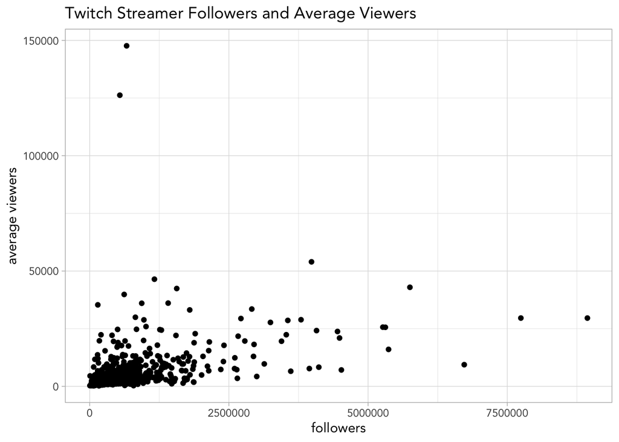

```r
p4 <- ggplot(twitch_data, aes(followers, average_viewers)) +
  geom_point() +
  labs(title = "Twitch Streamer Followers and Average Viewers",
       x = "followers",
       y = "average viewers")

# Showing plot
p4
```

Given how right skewed these variables are, the scatterplot of their raw values doesn’t provide much view on whats happening among most streamers.

Let’s transform the variables to get a better view.

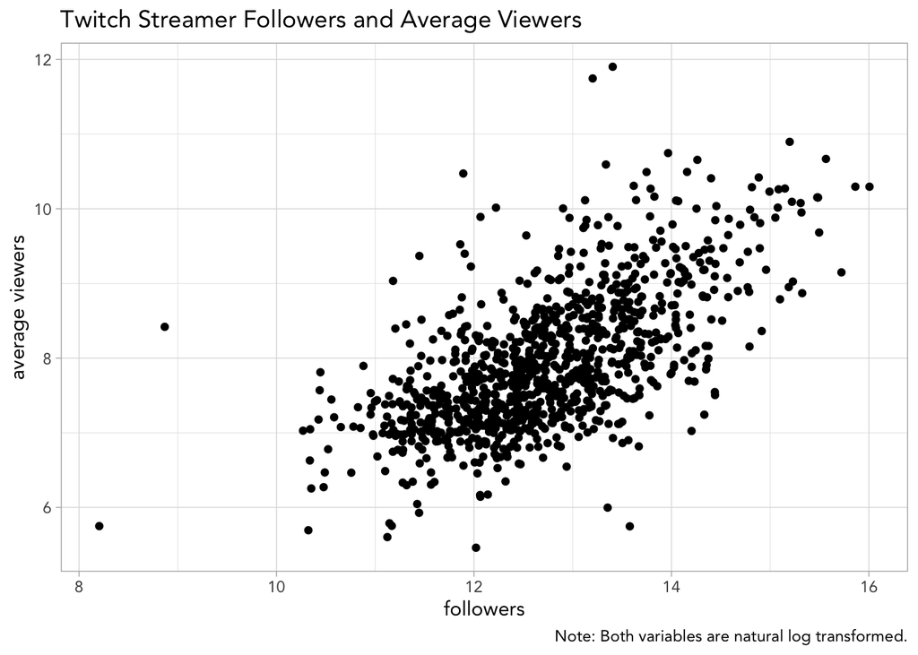

```r
# The textbook uses log base 10. I'm doing both base 10 and base *e* to see what the difference is.
twitch_data <- twitch_data %>%
  mutate(log_followers = log(followers),
         log_viewers = log(average_viewers),
         log10_followers = log10(followers),
         log10_viewers = log10(average_viewers))

p5 <- ggplot(twitch_data, aes(log_followers, log_viewers)) +
  geom_point() +
  labs(title = "Twitch Streamer Followers and Average Viewers",
       caption = "Note: Both variables are natural log transformed.",
       x = "followers",
       y = "average viewers")

p6 <- ggplot(twitch_data, aes(log10_followers, log10_viewers)) +
  geom_point() +
  labs(title = "Twitch Streamer Followers and Average Viewers",
       caption = "Note: Both variables are log transformed.",
       x = "followers",
       y = "average viewers")

# The difference in log base is of equal proportion scaling. I'll just go with base *e* out of preference

# Showing plot
p5
```

After transforming both variables, a strong positive association emerges between the logged follower and viewer variables. This indicates that there is a positive association; however, the strength is likely visually overstated because of the transformation.

## Q2

### Interpreting regression with transformed variables

Let’s take the variables we have just created and model the relationship.

```r
fit1 <- lm(log_viewers ~ log_followers,
           data = twitch_data)

# or summary(fit1)
tidy(fit1)
```

| term | estimate | std.error | statistic | p.value |
| --- | --- | --- | --- | --- |
| (Intercept) | 0.4555340 | 0.2884603 | 1.579192 | 0.114609 |
| log_followers | 0.5884958 | 0.0225979 | 26.042115 | 0.000000 |

A 10% increase in followers among twitch streamers is associated with a 5.88% increase in the average number of viewers.

## Q3

### Modeling relationship between followers and viewership

```r
# Getting fitted values and residuals
  # fitted values are the predicted values of y for each set of covariate combinations. Residuals are the difference with respect to y between the observed and predicted values.

pred_data <- augment(fit1)
```

Plotting observed data and fitted values

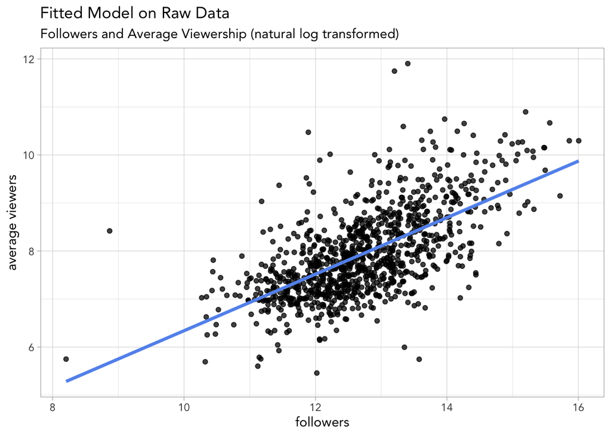

```r
p6 <- ggplot(pred_data, aes(log_followers, log_viewers)) +
  geom_point(alpha = 0.75) +
  geom_line(aes(log_followers, .fitted),
            col = "cornflowerblue",
            linewidth = 1.25) +
  labs(title = "Fitted Model on Raw Data",
       subtitle = "Followers and Average Viewership (natural log transformed)",
       x = "followers",
       y = "average viewers")

# Showing plot
p6
```

On the natural log scale, the model reasonably captures the relationship between followers and average followers.

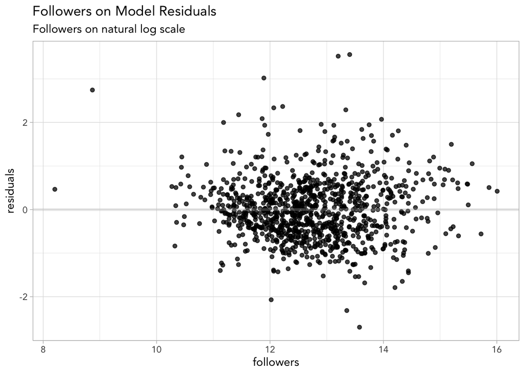

```r
p7 <- ggplot(pred_data, aes(log_followers, .resid)) +
  geom_point(alpha = 0.75) +
  geom_hline(yintercept = 0,
             linewidth = 1.25,
             color = "grey",
             alpha = 0.3) +
  labs(title = "Followers on Model Residuals",
       subtitle = "Followers on natural log scale",
       x = "followers",
       y = "residuals")

# Showing plot
p7
```

Looking at the distribution of residuals, there does not appear to be any systematic concentrations of residuals. This indicates that the model (that is, the line) does not systematically over or underestimate the data.

## Q4

### Exporatory Data Analysis for categorical x numerical

To begin looking at the raw data, I’ll look at some random samples of average viewers across languages.

Here, I pull 1 randomly selected streamers from each language and show their average viewers (There is only 1 streamer each for Greek, Finish, Slovak, and Swedish, and 2 for Hungarian).

```r
twitch_data %>%
  select(language, average_viewers) %>%
  group_by(language) %>%
  sample_n(size = 1)
```

| language | average_viewers |
| --- | --- |
| Arabic | 7265 |
| Chinese | 1412 |
| Czech | 978 |
| English | 3312 |
| Finnish | 1027 |
| French | 10516 |
| German | 1828 |
| Greek | 1961 |
| Hungarian | 2688 |
| Italian | 3836 |
| Japanese | 13675 |
| Korean | 3992 |
| Other | 1149 |
| Polish | 1118 |
| Portuguese | 900 |
| Russian | 1929 |
| Slovak | 2072 |
| Spanish | 1234 |
| Swedish | 1027 |
| Thai | 1052 |
| Turkish | 2217 |

This raw data is nice to look at but isn’t so informative if we want to discern the relation between languages spoken and average viewers.

We can try to get a better sense by looking at averages among the average viewership of streamers who speak different languages.

```r
twitch_data %>%
  group_by(language) %>%
  summarize(average_viewers_language = mean(average_viewers)) %>%
  arrange(desc(average_viewers_language))
```

| language | average_viewers_language |
| --- | --- |
| Russian | 6594.230 |
| Spanish | 6449.691 |
| Arabic | 5682.200 |
| English | 5112.814 |
| Japanese | 4762.600 |
| Turkish | 4760.864 |
| German | 4278.184 |
| Korean | 3913.883 |
| Portuguese | 3800.934 |
| French | 3506.530 |
| Chinese | 3424.800 |
| Polish | 2905.250 |
| Italian | 2205.529 |
| Hungarian | 2140.500 |
| Slovak | 2072.000 |
| Thai | 2011.364 |
| Greek | 1961.000 |
| Czech | 1827.667 |
| Other | 1149.000 |
| Finnish | 1027.000 |
| Swedish | 1027.000 |

This view at the data indicates that, on average, Twitch streamers who speak Russian, Spanish, Arabic, English, and Japanese are in the top 5 of average viewership.

### Visualizing average viewership across languages

Let’s plot the distributions of average viewership across languages.

First, we’ll visualize the distribution of average viewers by language without doing any transformations.

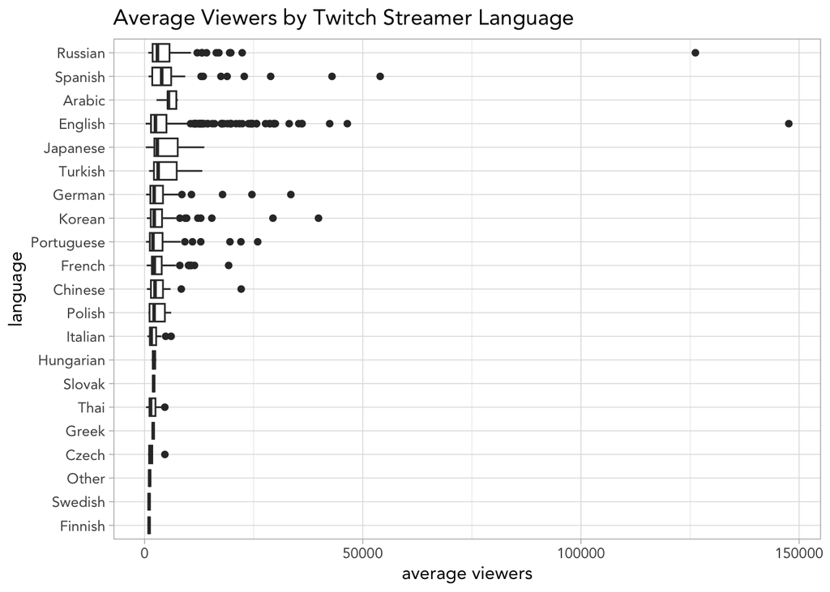

```r
p8 <- ggplot(twitch_data,
             aes(reorder(language, average_viewers),
                 average_viewers)) +
  geom_boxplot() +
  labs(title = "Average Viewers by Twitch Streamer Language",
       x = "language", # axis titles are swapped
       y = "average viewers") +
  coord_flip()

# Showing plot
p8
```

Just with the raw data, it is difficult to compare between languages because of how right skewed the distributions are. To get a better look at the differences between languages, we’ll first look more closely at streamers with less than or equal to 10,000 average viewers. This excludes about 10% of the data but gives us a better look at the majority of the distributions.

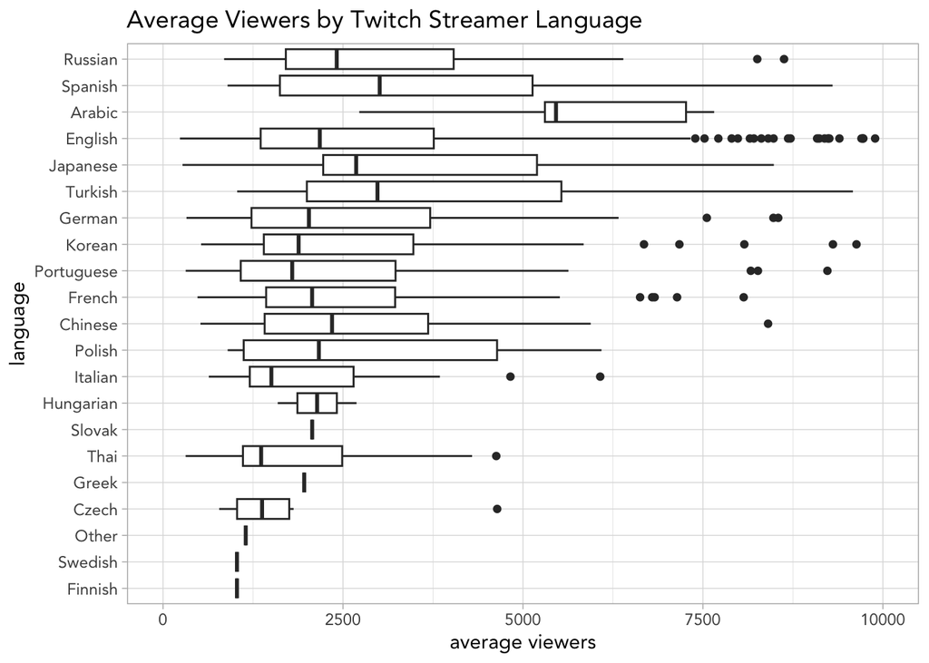

```r
p9 <- twitch_data %>%
  ggplot(aes(reorder(language, average_viewers),
             average_viewers)) +
  geom_boxplot() +
  labs(title = "Average Viewers by Twitch Streamer Language",
       x = "language", # axis titles are swapped
       y = "average viewers") +
  ylim(0, 10000) +
  coord_flip()

# Showing plot
p9
```

```r
# Seeing how much is excluded by filtering to >= 10000 (about 10%)
d <- twitch_data %>%
  group_by(language) %>%
  summarize(raw = n())

d2 <- twitch_data %>%
  filter(average_viewers <= 10000) %>%
  group_by(language) %>%
  summarize(filter = n())

d3 <- full_join(d, d2, by = "language") %>%
  summarize(raw = sum(raw),
            filter = sum(filter),
            diff = raw - filter,
            prop = diff / raw)
```

Zooming in on the majority of streamers with less than 10,000 average viewers gives us a better picture of the differences between languages.

For another perspective on these rankings, let’s see how it would look by using the natural log transformed distributions.

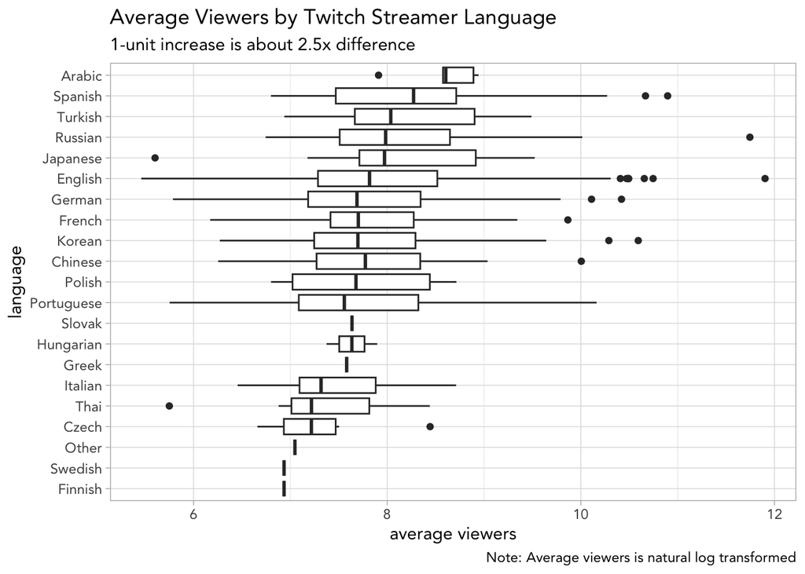

```r
p10 <- ggplot(twitch_data,
             aes(reorder(language, log_viewers),
                 log_viewers)) +
  geom_boxplot() +
  labs(title = "Average Viewers by Twitch Streamer Language",
       subtitle = "1-unit increase is about 2.5x difference",
       caption = "Note: Average viewers is natural log transformed",
       x = "language",
       y = "average viewers") +
  coord_flip()

p10
```

This view provides mostly the same information besides a slightly different ranking.

## Q5

### Regression with categorical variable

Defining language as a factor variable with English as the reference category.

```r
twitch_data <- twitch_data %>%
  mutate(language_fac = as.factor(language),
         language_fac = relevel(language_fac, ref = "English"))
```

Estimating and visualizing average viewers by language with natural log transformation on outcome.

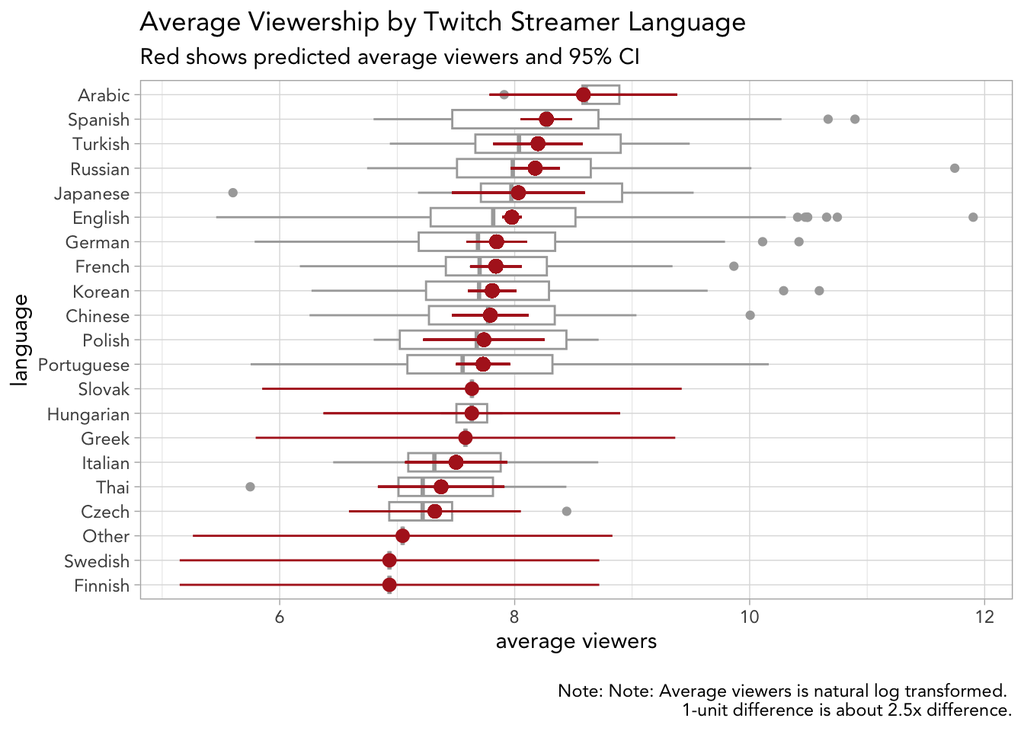

```r
fit3 <- lm(log_viewers ~ language_fac,
         data = twitch_data)

fit3_tidy <- tidy(fit3)


fit3_pred <- augment(fit3, se_fit = TRUE) %>%
  distinct(language_fac, .fitted, .se.fit) %>%
  mutate(lower = .fitted + qnorm(0.025) * .se.fit,
         upper = .fitted + qnorm(0.975) * .se.fit) %>%
  rename("language" = language_fac)


viewer_data <- twitch_data %>%
  select(language, log_viewers)


fit3_preddata <- full_join(fit3_pred, viewer_data, by = "language")

p10 <- ggplot(fit3_preddata) +

  # Boxplots of raw data
  geom_boxplot(aes(x = log_viewers,
                   y = reorder(language, log_viewers)),
               color = "darkgrey") +

  # Point ranges of predicted values with 95% CI
  geom_pointrange(aes(x = .fitted,
                      y = reorder(language, log_viewers),
                      xmin = lower,
                      xmax = upper),
                  color = "firebrick") +

  labs(title = "Average Viewership by Twitch Streamer Language",
       subtitle = "Red shows predicted average viewers and 95% CI",
       x = "average viewers",
       y = "language",
       caption = "\n Note: Note: Average viewers is natural log transformed. \n 1-unit difference is about 2.5x difference.")

# Would be cool to display title words with same color used (the word "Red" is displays in the same color and Grey (maybe with ggtext package))

# Show plot
p10
```

## Q6

### Plotting residuals of language on average viewers

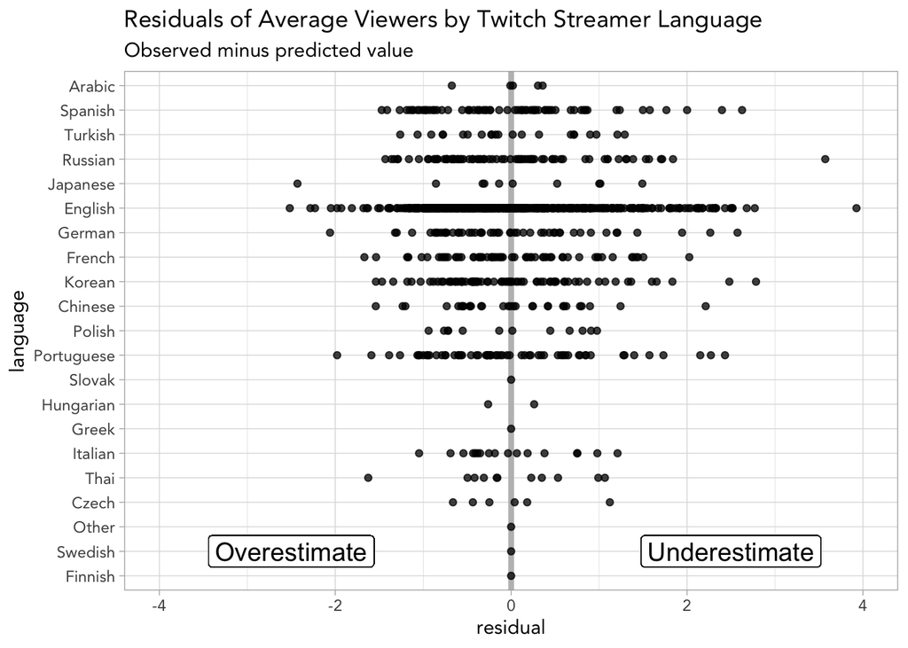

```r
# Grabbing residuals with `augment()`
augment(fit3) %>%

  rename("language" = language_fac) %>%

  ggplot(aes(x = reorder(language, .fitted),
             y = .resid)) +

  # Showing line for observed = predicted
  geom_hline(yintercept = 0,
             linewidth = 1.5,
             color = "grey") +

  # plotting residuals
  geom_point(alpha = 0.75) +

  # Labeling sides as over or underestimates
  geom_label(x = "Swedish",
            y = -2.5,
            label = "Overestimate",
            size = 5) +

  geom_label(x = "Swedish",
             y = 2.5,
             label = "Underestimate",
             size = 5) +
  # For readability of language labels
  coord_flip() +

  # symmetric display of residuals
  ylim(-4, 4) +

  labs(title = "Residuals of Average Viewers by Twitch Streamer Language",
       subtitle = "Observed minus predicted value",
       x = "language",
       y = "residual")
```

However, seeing how the model overestimates and underestimates the average viewer count of Portuguese, Russian, English, German, and other languages by around 7x, the model doesn’t provide the best prediction of average viewers.